# 山昆チョウデータベースにおける現状

Author

佐野孔亮

# はじめに

山形昆虫同好会では県内の昆虫の採集や分布の記録を電子データ化しようという試みがなされており、先人達の努力により各分類群において長大なデータフレームが構築されている。しかし、それらデータは入力の形式に齟齬があったり、誤入力と思われるデータが存在したり、いくつかの種や地域で漏れや抜けがあったりと、完全なデータベースではない。

今回の報文では、チョウ類のデータに限定し、各種の **「記録上最も早い確認」**、**「記録上最も遅い確認」**、**「記録のある市区町村」**の3項目について整理し報告する。これらはあくまで山昆のデータベース上に現時点で入力されているものであり、絶対的な信頼性が担保されている訳ではないことにご留意願いたい。漏れや抜けの情報をお持ちの方は、ぜひそれらデータを山昆の方へ共有していただけると幸いである。この報告を叩き台として、山昆のデータベースがより正確で利用しやすいものとなることを願う。

# 各種のデータ

## アゲハチョウ科

### ギフチョウ

**早い記録**

```
    採集日時 累計日数 市町村名           詳細地名 個体数   採集者
1 1997-03-03       62   鮭川村         鮭川村真木      1 横倉　明
2 1983-03-04       63   鮭川村         鮭川村真木      1 高橋清志
3 1989-03-13       72   鶴岡市       鶴岡市高館山      1 畠中裕之
4 1968-03-18       78 大石田町       大石田町川前      1 木俣　繁
5 1989-03-20       79   小国町             小国町      1 黒沼孝一
6 2013-03-21       80   飯豊町     飯豊町源流の森      1 会田　晋
7 1989-03-21       80   小国町             小国町      1 黒沼孝一
8 2002-03-21       80   鶴岡市 鶴岡市大山町八森山      2 水野重紀
9 1990-03-23       82   小国町             小国町      2 黒沼孝一
            引用文献           備考
1       蝶類年鑑2001     斑紋異常型
2    出羽のむしＮｏ9       マルギフ
3 山形おもしろ昆虫誌
4     山形博物昆虫10 飼育？自然交雑
5     山形博物昆虫10         飼育？
6    出羽のむしＮｏ9   燐粉異常個体
7     山形博物昆虫10         飼育？
8    鶴岡自然誌Ｎｏ7
9     山形博物昆虫10         飼育？
```

**遅い記録**

```
     採集日時 累計日数 市町村名         詳細地名 個体数   採集者
1  1978-08-14      226   小国町           小国町      1 黒沼孝一
2  2012-07-03      185   西川町     西川町田代沢      1 大高　力
3  2013-07-02      183   西川町     西川町田代沢      1 本木俊一
4  2013-07-02      183   西川町           (860m)      1
5  2012-06-29      181   西川町     西川町田代沢      2 鈴木幸治
6  2012-06-27      179   西川町     西川町田代沢      1 鈴木幸治
7  2001-06-28      179   鶴岡市 櫛引町たらのき代      2 相蘇　尚
8  2005-06-26      177   鶴岡市 櫛引町たらのき代      1 相蘇　尚
9  2012-06-24      176   西川町     西川町田代沢      7 横山　仁
10 2013-06-25      176   西川町     西川町田代沢      1 秋葉国広
11 2006-06-25      176   鶴岡市     鶴岡市長坊山      2 西村昌幸
                       引用文献           備考
1                山形博物昆虫10
2  山形昆虫大賞ノメネ－トＮｏ11
3              朝日新聞2013.7.6 Ｈ13まで最も遅
4               珠玉の標本箱No9
5  山形昆虫大賞ノメネ－トＮｏ11 Ｈ12まで最も遅
6              出羽のむしＮｏ10
7              出羽のむしＮｏ10
8              出羽のむしＮｏ10
9              出羽のむしＮｏ10
10             出羽のむしＮｏ10
11             出羽のむしＮｏ10
```

**生息している市町村**

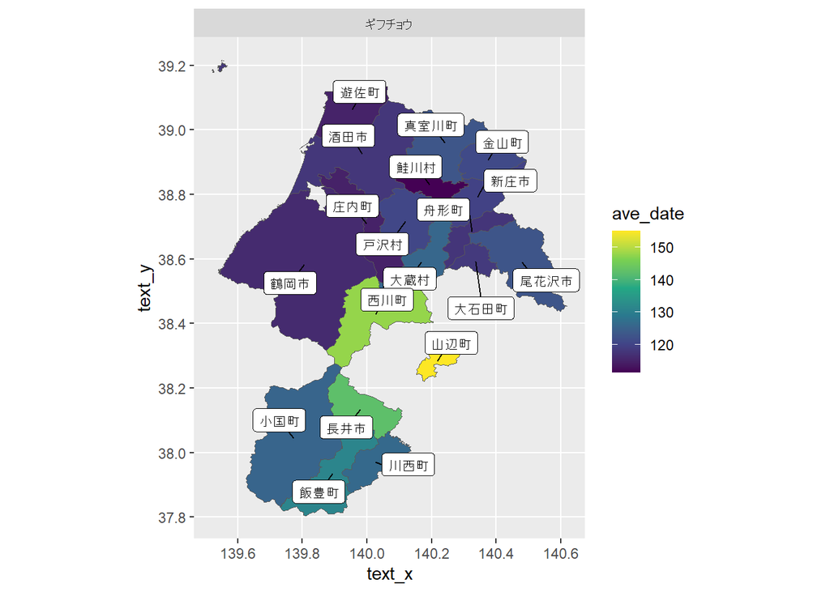

### ヒメギフチョウ

**早い記録**

```
     採集日時 累計日数 市町村名     詳細地名 個体数   採集者
1  1989-03-02       61   鮭川村   鮭川村中渡      1 黒沼孝一
2  1974-03-10       69 大石田町 大石田町川前      1
3  1985-03-18       77 大石田町 大石田町川前      1 横倉　明
4  1990-03-18       77   鮭川村   鮭川村真木      1 黒沼孝一
5  1990-03-21       80   鮭川村   鮭川村真木      3 黒沼孝一
6  1976-03-21       81   米沢市       米沢市     11 菅原　亮
7  1990-03-23       82   鮭川村   鮭川村真木      1 黒沼孝一
8  1989-03-24       83   鮭川村   鮭川村真木      1 黒沼孝一
9  1989-03-25       84   鮭川村   鮭川村中渡      4 黒沼孝一
10 1990-03-26       85   鮭川村   鮭川村真木      1 黒沼孝一
                 引用文献             備考
1          山形博物昆虫10           飼育？
2       寒河江川流域Ｎｏ6
3  山形県のヒメギフチョウ 雑種第１代（Ｆ）
4          山形博物昆虫10           飼育？
5          山形博物昆虫10           飼育？
6           にらがみＮｏ9         飼育羽化
7          山形博物昆虫10           飼育？
8          山形博物昆虫10           飼育？
9          山形博物昆虫10           飼育？
10         山形博物昆虫10           飼育？
```

**遅い記録**

```
    採集日時 累計日数 市町村名                詳細地名 個体数     採集者
1 1977-09-12      255   舟形町              舟形町長沢      1 白畑孝太郎
2 1981-08-07      219   山形市        山形市西蔵王高原      1   黒沼孝一
3 1965-07-25      206   西川町 西川町大井沢峠（850ｍ）      1   佐藤　敬
4 2003-07-17      198   高畠町        高畠町二井宿田沢      2   島津昌弘
5 2014-06-27      178   東根市            東根市遠尊沢      4   大高　力
6 1984-06-05      157   戸沢村              戸沢村長倉      1   武田　隆
              引用文献               備考
1       山形博物昆虫10
2       山形博物昆虫10
3 東北昆虫研究3（1/2）       最も遅い記録
4     出羽のむしＮｏ13
5     出羽のむしＮｏ10
6      出羽のむしＮｏ5 ギフチョウの交尾嚢
```

**生息している市町村**

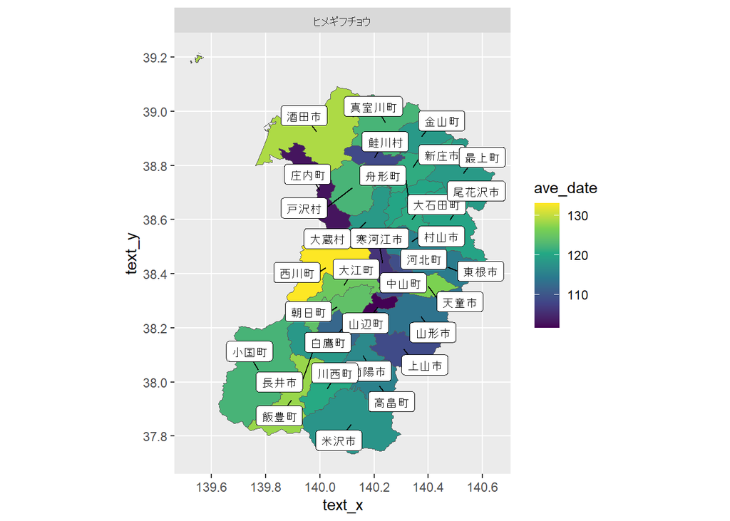

### ウスバアゲハ（ウスバシロチョウ）

**早い記録**

```
    採集日時 累計日数 市町村名                 詳細地名 個体数   採集者
1 2003-04-08       98   山形市             山形市長谷堂      2 粟野省三
2 2004-04-08       99   白鷹町               白鷹町荒砥      2 粟野省三
3 2002-04-27      117   山形市         山形市長谷堂漆房      2 粟野省三
4 2002-04-29      119   鶴岡市             温海町温海岳      3 本木俊一
5 2005-05-01      121   山形市         山形市みのりが丘      1 粟野省三
6 1998-05-02      122   鶴岡市               鶴岡市谷定      2 本木俊一
7 2003-05-03      123   朝日町               朝日町杉山      1 本木俊一
8 2002-05-04      124   長井市 長井市日出町最上川河川敷      2 大高　力
9 1998-05-04      124   遊佐町               遊佐町金俣      1 本木俊一
         引用文献 備考
1 出羽のむしＮｏ5
2 出羽のむしＮｏ5
3 出羽のむしＮｏ5
4 出羽のむしＮｏ6
5 出羽のむしＮｏ5
6 出羽のむしＮｏ6
7 出羽のむしＮｏ6
8 出羽のむしＮｏ6
9 出羽のむしＮｏ6
```

**遅い記録**

```
    採集日時 累計日数 市町村名         詳細地名 個体数     採集者
1 2010-07-18      199   小国町     小国町温身平      1   佐藤敏幸
2 1971-07-10      191   米沢市       米沢市滑川      1   高橋清志
3 1969-07-09      190   小国町       小国町大石      1 白畑孝太郎
4 1969-07-09      190   小国町     小国町伊佐領      1   藤田幸夫
5 1984-07-07      189   飯豊町       飯豊町岳谷      4   早坂公夫
6 1992-07-06      188   西川町       西川町志津      1   武田　隆
7 1987-07-06      187   朝日村   朝日村朝日地区      1   草刈広一
8 1970-07-01      182   小国町     小国町温身平     19 白畑孝太郎
9 2009-06-30      181   西川町 西川町大井沢中上      1   大高　力
          引用文献 備考
1 出羽のむしＮｏ10
2  らふぁえりすNo3
3  山形県博物昆虫1
4  山形県博物昆虫1
5   山形博物昆虫10
6  出羽のむしＮｏ5
7         山昆誌16
8  山形県博物昆虫1
9  出羽のむしＮｏ6
```

**生息している市町村**

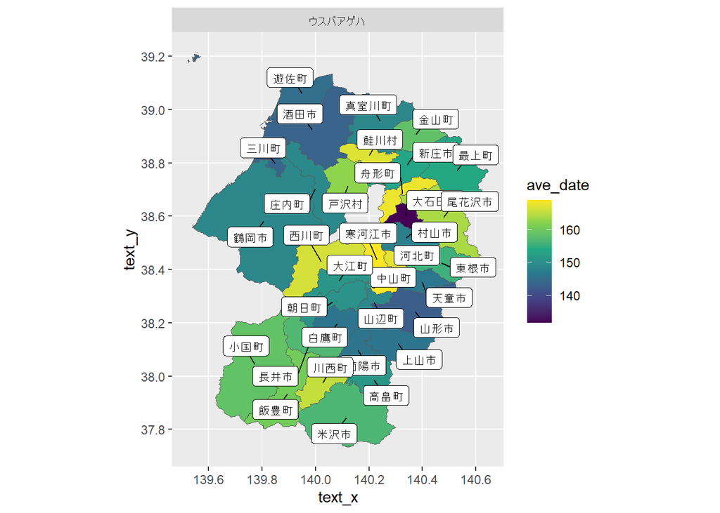

### ジャコウアゲハ

**早い記録**

```
     採集日時 累計日数 市町村名                 詳細地名 個体数   採集者
1  2004-04-19      110   庄内町           立川町上出川原      1 本木俊一
2  1989-04-22      112 大石田町                 大石田町      1 黒沼孝一
3  2001-04-22      112   庄内町           立川町上出川原      1 本木俊一
4  1989-04-25      115 大石田町                 大石田町      4 黒沼孝一
5  1989-04-26      116 大石田町                 大石田町      1 黒沼孝一
6  2001-04-27      117   庄内町           立川町上出川原      2 本木俊一
7  2017-05-02      122   山形市     山形市馬見ケ崎川左岸      1 長岡久人
8  2001-05-03      123   庄内町           立川町上出川原      2 本木俊一
9  2005-05-04      124   長井市 長井市日出町最上川河川敷      2 大高　力
10 2002-05-04      124   庄内町       立川町狩川原河川敷      1 川崎定広
           引用文献             備考
1   出羽のむしＮｏ6
2    山形博物昆虫10
3   出羽のむしＮｏ6
4    山形博物昆虫10
5    山形博物昆虫10
6   出羽のむしＮｏ6
7  出羽のむしＮｏ13
8   出羽のむしＮｏ6
9   出羽のむしＮｏ6
10  出羽のむしＮｏ2 異常個体（飼育）
```

**遅い記録**

```
    採集日時 累計日数 市町村名     詳細地名 個体数   採集者        引用文献
1 2012-11-05      310   上山市   上山市金瓶      2 会田　晋 出羽のむしＮｏ8
2 2004-09-18      262   白鷹町 白鷹町下思川      1 大高　力 出羽のむしＮｏ6
3 1996-09-14      258   遊佐町 遊佐町湯の田      1 本木俊一 鶴岡自然誌Ｎｏ6
4 1999-09-09      252   酒田市 松山町大川渡      1 本木俊一 出羽のむしＮｏ6
   備考
1 第4科
2
3
4
```

**生息している市町村**

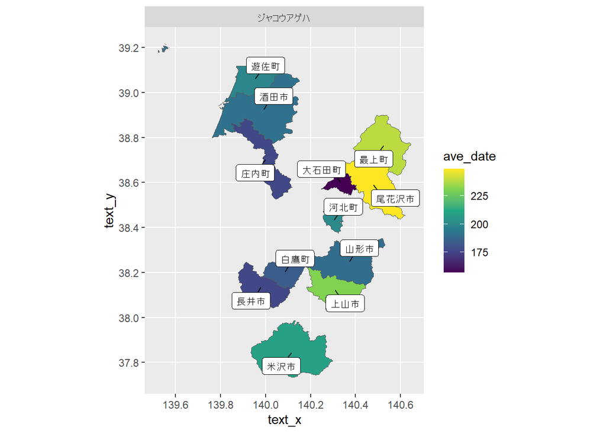

### キアゲハ

**早い記録**

```
    採集日時 累計日数 市町村名           詳細地名 個体数   採集者
1 2016-03-31       91 寒河江市     寒河江市慈恩寺      1 島津昌弘
2 1963-04-06       96   山形市         山形市盃山      2 長岡久人
3 2007-04-10      100 寒河江市     寒河江市慈恩寺      2 大高　力
4 1954-04-11      101   山形市         山形市盃山      1 伊藤義穂
5 2016-04-10      101   白鷹町 白鷹町高玉釜の越桜      1 大高　力
6 2004-04-12      103 寒河江市     寒河江市慈恩寺      1 武田　隆
7 2002-04-15      105   酒田市       酒田市大森山      2 本木俊一
8 2011-04-15      105     <NA>   鶴岡市藤島藤島川      1 山本英夫
9 2009-04-19      109     <NA>       鶴岡市馬渡山      1 山本英夫
             引用文献 備考
1    出羽のむしＮｏ12
2     出羽のむしＮｏ6
3     出羽のむしＮｏ6
4 しゅめてりんげＮｏ3
5    出羽のむしＮｏ12
6     出羽のむしＮｏ5
7     出羽のむしＮｏ6
8    鶴岡自然誌Ｎｏ15
9    鶴岡自然誌Ｎｏ15
```

**遅い記録**

```
     採集日時 累計日数 市町村名               詳細地名 個体数   採集者
1  1999-11-10      314   山形市           山形市東原町      1
2  2010-10-11      284   山形市       山形市西蔵王土坂      1 大高　力
3  1996-10-03      277   小国町           小国町白子沢      1 草刈広一
4  2009-09-30      273   村山市   村山市楯山とその周辺      1 土谷義幸
5  2011-09-29      272   朝日町             朝日町送橋      1 大高　力
6  1974-09-29      272   小国町       小国町北～田沢頭      1 武田　隆
7  1981-09-27      270   鮭川村           鮭川村小舟山      1 武田　隆
8  1983-09-25      268   鶴岡市   鶴岡市大山下池～上池      1 武田　隆
9  2007-09-24      267   村山市 村山市田沢じゅんさい沼      1 武田　隆
10 2011-09-24      267   戸沢村             戸沢村蔵岡      1 大高　力
                 引用文献 備考
1          山形博物昆虫10
2           出羽のむしNo7
3  ファウナウキタムＮｏ54
4         出羽のむしＮｏ6
5        出羽のむしＮｏ10
6         出羽のむしＮｏ5
7         出羽のむしＮｏ5
8         出羽のむしＮｏ5
9         出羽のむしＮｏ5
10        出羽のむしＮｏ8
```

**生息している市町村**

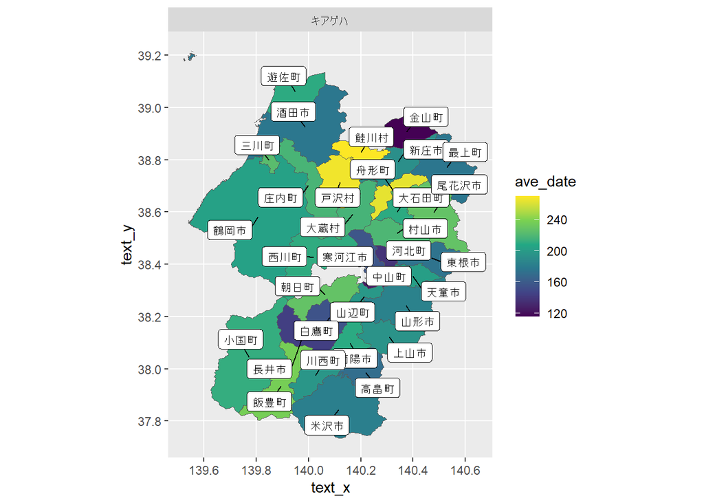

### ナミアゲハ

**早い記録**

```
    採集日時 累計日数 市町村名             詳細地名 個体数   採集者
1 1956-04-12      103   羽黒町       羽黒町赤川右岸      1 本木俊一
2 2002-04-22      112   鶴岡市         藤島町古楯跡      1 山本英夫
3 1959-04-28      118   鶴岡市         鶴岡市鳥居町      1 本木俊一
4 2005-05-01      121   山形市           山形市盃山      1 長岡久人
5 2007-05-01      121   鶴岡市         鶴岡市千石町      1 本木俊一
6 2008-05-01      122   村山市 村山市楯山とその周辺      1 土谷義幸
7 2015-05-02      122 寒河江市       寒河江市慈恩寺      1 島津昌弘
8 1955-05-02      122   鶴岡市         鶴岡市鳥居町      1 本木俊一
9 1975-05-03      123   山形市           山形市盃山      1 武田　隆
          引用文献 備考
1  出羽のむしＮｏ6
2 鶴岡自然誌Ｎｏ15
3  出羽のむしＮｏ6
4 出羽のむしＮｏ11
5  出羽のむしＮｏ6
6  出羽のむしＮｏ6
7 出羽のむしＮｏ11
8  出羽のむしＮｏ6
9  出羽のむしＮｏ5
```

**遅い記録**

```
    採集日時 累計日数 市町村名     詳細地名 個体数   採集者         引用文献
1 2002-10-04      277   鶴岡市 鶴岡市千石町      1 本木俊一  出羽のむしＮｏ6
2 1999-09-15      258   鶴岡市 鶴岡市千石町      1 本木俊一  出羽のむしＮｏ6
3 1991-09-07      250   酒田市 酒田市大森山      1 山本英夫 鶴岡自然誌Ｎｏ15
4 1979-09-05      248   山形市       山形市      1 黒沼孝一   山形博物昆虫10
5 1988-08-30      243   鶴岡市 藤島町古楯跡      1 山本英夫 鶴岡自然誌Ｎｏ15
6 1975-08-30      242   山形市   山形市神尾      1 武田　隆  出羽のむしＮｏ5
7 1988-08-27      240   鶴岡市 藤島町古楯跡      1 山本英夫 鶴岡自然誌Ｎｏ15
  備考
1
2
3
4
5
6
7
```

**生息している市町村**

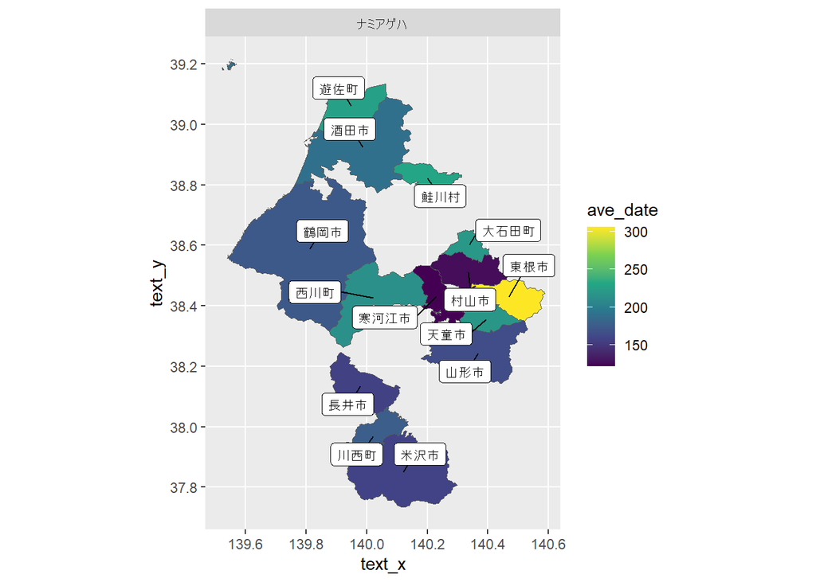

### オナガアゲハ

**早い記録**

```
     採集日時 累計日数 市町村名                               詳細地名 個体数
1  2008-05-06      127   山形市                             山形市盃山      1
2  1964-05-10      131   山形市                             山形市盃山      2
3  2016-05-12      133   山形市                           山形市富神山      1
4  1970-05-13      133   米沢市                           米沢市愛宕山      1
5  1969-05-14      134   天童市                   天童市下萩戸北沢　　      1
6  1983-05-15      135   天童市 天童市田麦俣天童高原～山形市山寺面白山      2
7  1954-05-15      135   鶴岡市               鶴岡市天神町（現神明町）      1
8  1967-05-16      136   東根市                             東根市神町      1
9  1964-05-17      138   山形市                             山形市東沢      2
10 1964-05-17      138   山形市             山形市妙見寺月の輪古墳付近      2
11 1995-05-18      138   酒田市                             酒田市北堤      1
12 1970-05-18      138   酒田市                       酒田市生石柳沢池      1
       採集者               引用文献 備考
1    武田　隆        出羽のむしＮｏ5
2    長岡久人        出羽のむしＮｏ6
3    島津昌弘       出羽のむしＮｏ12
4    山谷文仁 ファウナウキタムＮｏ55
5  白畑孝太郎        山形県博物昆虫1
6    武田　隆        出羽のむしＮｏ5
7    本木俊一        出羽のむしＮｏ6
8  白畑孝太郎         山形博物昆虫10
9  長岡亮太郎        らふぁえりすNo3
10   長岡久人        出羽のむしＮｏ6
11   岡部光一             酒田の昆虫
12 白畑孝太郎        山形県博物昆虫1
```

**遅い記録**

```
    採集日時 累計日数 市町村名                 詳細地名 個体数     採集者
1 2006-09-02      245   上山市             上山市元屋敷      1   大高　力
2 1980-08-31      244   山形市 山形市山寺馬形～二口追分      1   武田　隆
3 1979-09-01      244   山形市             山形市西蔵王      1   黒沼孝一
4 1993-08-29      241   鶴岡市             鶴岡市高館山      2   山本英夫
5 1969-08-27      239   川西町               川西町駄子      1 白畑孝太郎
6 1968-08-25      238   小国町               小国町松岡      1   渡部　正
7 1999-08-25      237   酒田市             松山町柏谷沢      1   櫻井俊一
8 1972-08-23      236   米沢市               米沢市米沢      1   山谷文仁
9 2012-08-21      234   山形市       山形市高瀬戸沢林道      1   大高　力
                引用文献 備考
1        出羽のむしＮｏ6
2        出羽のむしＮｏ5
3         山形博物昆虫10
4       鶴岡自然誌Ｎｏ15
5         山形博物昆虫10
6     藤田小国中標本目録
7           松山町の昆虫
8 ファウナウキタムＮｏ55
9       出羽のむしＮｏ10
```

**生息している市町村**

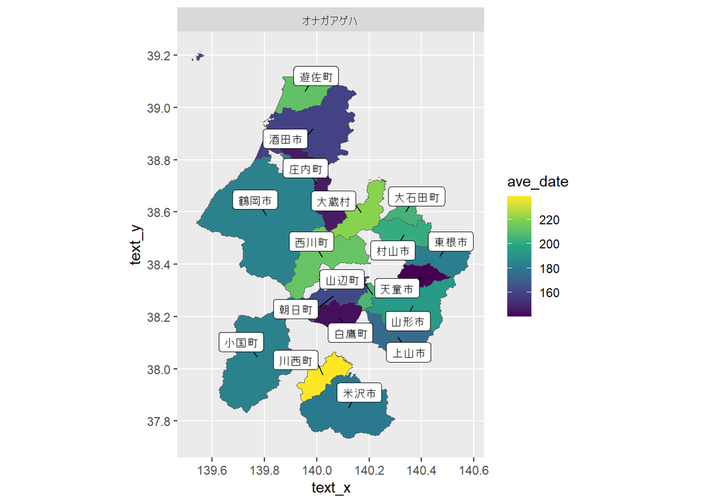

### モンキアゲハ

**早い記録**

```
     採集日時 累計日数 市町村名                 詳細地名 個体数
1  2008-06-08      160   鶴岡市             鶴岡市高館山      1
2  2002-07-30      211   鶴岡市             鶴岡市高館山      3
3  2002-07-31      212   鶴岡市             鶴岡市高館山     10
4  2002-08-01      213   鶴岡市             鶴岡市高館山      5
5  2002-08-01      213   鶴岡市 鶴岡市高館山湯野浜コ－ス      1
6  2002-08-06      218   鶴岡市             鶴岡市高館山      1
7  2002-08-07      219   鶴岡市             鶴岡市高館山      1
8  1970-08-13      225   上山市             上山市三吉山      1
9  2002-08-18      230   最上町               最上町境田      1
10 1980-08-17      230   酒田市 酒田市飛島（さいノ河原）      1
             採集者         引用文献 備考
1          本木俊一 鶴岡自然誌Ｎｏ12
2          柴田　捻  鶴岡自然誌Ｎｏ7
3          水野重紀  鶴岡自然誌Ｎｏ7
4  水野、柴田、本木  鶴岡自然誌Ｎｏ7
5          本木俊一  出羽のむしＮｏ6
6          横倉　明  鶴岡自然誌Ｎｏ7
7          山本英夫  鶴岡自然誌Ｎｏ7
8          木村　充    山昆虫誌Ｎｏ4
9          大高　力  出羽のむしＮｏ6
10           宇佐美       酒田の昆虫
```

**遅い記録**

```
     採集日時 累計日数 市町村名                     詳細地名 個体数
1  2013-09-24      267   鶴岡市                 鶴岡市高館山      1
2  2017-09-22      265   山形市                 山形市中桜田      1
3  2017-09-18      261   山形市                 山形市中桜田      1
4  1987-09-13      256   新庄市     新庄市小田島山新最上支部      1
5  2006-09-03      246   鶴岡市                 温海町天魄山      1
6  2002-09-01      244   鶴岡市                 鶴岡市高館山      1
7  2002-08-29      241   鶴岡市                 鶴岡市高館山      1
8  2016-08-24      237   山形市                 山形市中桜田      1
9  1970-08-21      233   上山市                 上山市三吉山      1
10 2010-08-21      233   鶴岡市 鶴岡市大山都沢（ａｌｔ13ｍ）      1
                 採集者                   引用文献 備考
1              本木俊一 第12山形昆虫大賞ノメネ－ト
2              大高　力           出羽のむしＮｏ13
3              大高　力           出羽のむしＮｏ13
4                                         新庄市史
5  梅津みどり・佐藤聖之           鶴岡自然誌Ｎｏ10
6              水野重紀            鶴岡自然誌Ｎｏ7
7              大高　力            出羽のむしＮｏ6
8              大高　力           出羽のむしＮｏ12
9              木村　充            らふぁえりすNo3
10             水野重紀           鶴岡自然誌Ｎｏ14
```

**生息している市町村**

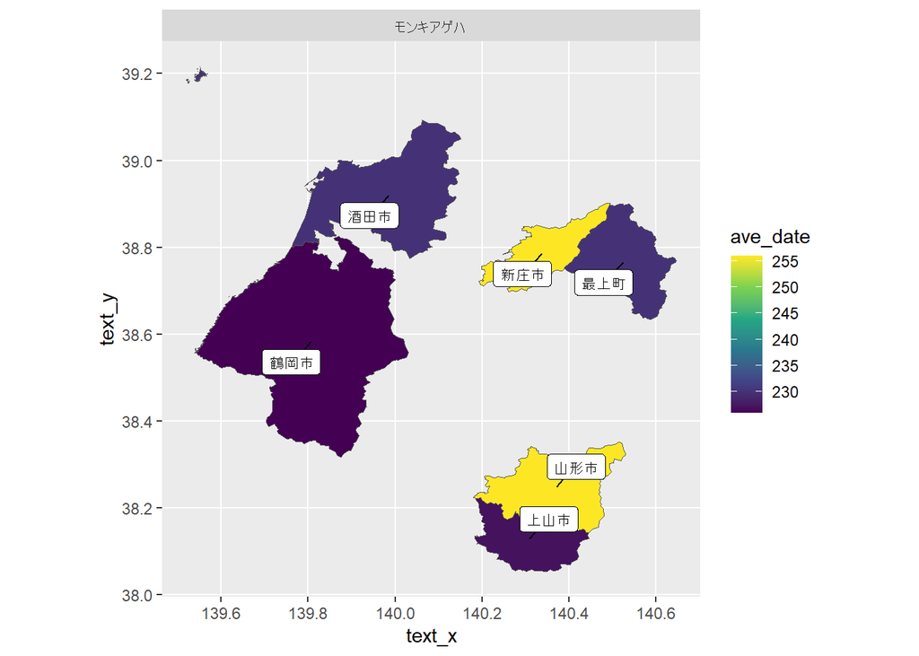

### クロアゲハ

**早い記録**

```
     採集日時 累計日数 市町村名       詳細地名 個体数   採集者         引用文献
1  1997-02-10       41   山形市   山形市東原町      2            山形博物昆虫10
2  1992-02-16       47   山形市   山形市東原町      4            山形博物昆虫10
3  1992-02-26       57   山形市   山形市東原町      1            山形博物昆虫10
4  1994-03-10       69   山形市   山形市東原町      1            山形博物昆虫10
5  1959-04-27      117   鶴岡市   鶴岡市鳥居町      1 本木俊一  出羽のむしＮｏ6
6  2015-05-03      123   上山市 上山市前川ダム      1 島津昌弘 出羽のむしＮｏ11
7  1991-05-06      126   山形市     山形市盃山      2 武田　隆  出羽のむしＮｏ5
8  1991-05-09      129   山形市         山形市      1            山形博物昆虫10
9  1963-05-12      132   山形市     山形市盃山      1 長岡久人  出羽のむしＮｏ6
10 2001-05-12      132   山形市     山形市盃山      1 粟野省三    出羽のむしNo4
     備考
1  飼育？
2  飼育？
3  飼育？
4  飼育？
5
6
7
8
9
10
```

**遅い記録**

```
    採集日時 累計日数 市町村名           詳細地名 個体数   採集者
1 1993-10-20      293   山形市       山形市東原町      2
2 2010-10-11      284   山形市   山形市西蔵王土坂      1 大高　力
3 2003-09-27      270   西川町   西川町間沢間沢川      1 阿部啓二
4 2013-09-24      267   鶴岡市       鶴岡市高館山      1 本木俊一
5 2006-09-22      265   長井市         長井市館町      1 大高　力
6 2017-09-16      259   山形市 山形市東原町清風荘      1 大高　力
7 1993-09-12      255   鶴岡市       藤島町古楯跡      1 山本英夫
8 2002-09-08      251   山形市 山形市和合町日月山      2 武田　隆
9 2009-09-07      250   河北町   河北町弥勒寺公園      1 大高　力
           引用文献     備考
1    山形博物昆虫10   飼育？
2   出羽のむしＮｏ7
3 寒河江川流域Ｎｏ6
4  鶴岡自然誌Ｎｏ20
5   出羽のむしＮｏ6
6  出羽のむしＮｏ13
7  鶴岡自然誌Ｎｏ15 やや短尾
8   出羽のむしＮｏ5
9   出羽のむしＮｏ6
```

**生息している市町村**

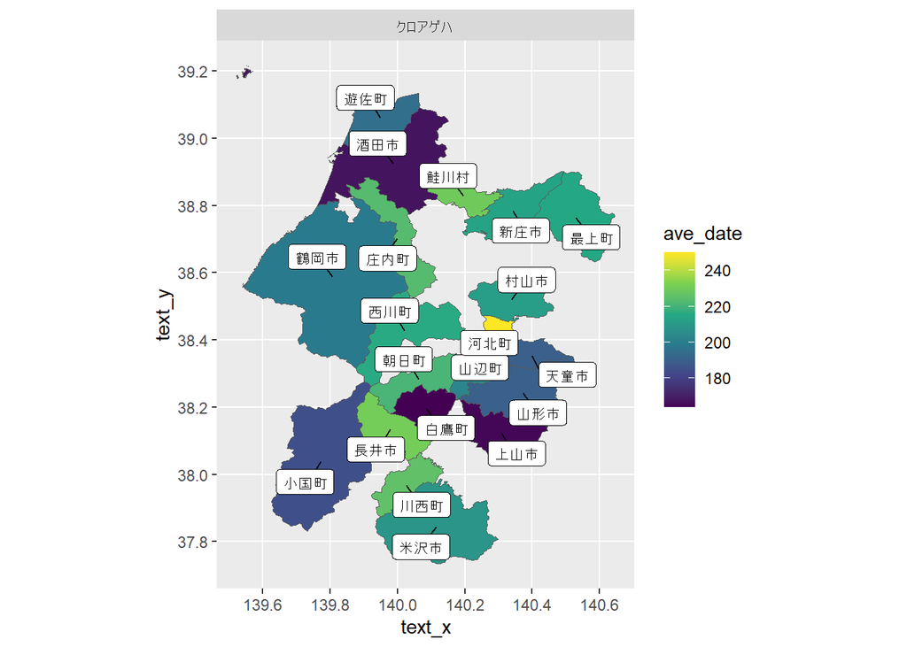

### カラスアゲハ

**早い記録**

```
     採集日時 累計日数 市町村名             詳細地名 個体数     採集者
1  2008-05-06      127   山形市           山形市盃山      1   武田　隆
2  1972-05-07      128   米沢市         米沢市早坂山      1   山谷文仁
3  1962-05-09      129   山形市         山形市千歳山      2   渡部　徳
4  2001-05-12      132   山形市           山形市盃山      1   粟野省三
5  2003-05-12      132   鶴岡市     鶴岡市高館山山頂      2   本木俊一
6  1970-05-13      133   米沢市         米沢市愛宕山      1   山谷文仁
7  1938-05-14      134   山形市   山形市師範グランド      1   志田金一
8  1938-05-15      135   山形市 山形市千歳山公園西方      1   大國五郎
9  1970-05-15      135   鶴岡市   鶴岡市三瀬気比神社      1 白畑孝太郎
10 1999-05-15      135   鶴岡市       温海町小菅野代      1   本木俊一
                    引用文献 備考
1            出羽のむしＮｏ5
2     ファウナウキタムＮｏ55
3  インセクトマップオブＮｏ8
4              出羽のむしNo4
5            出羽のむしＮｏ6
6     ファウナウキタムＮｏ55
7                       琴眞
8                       琴眞
9            山形県博物昆虫1
10           出羽のむしＮｏ6
```

**遅い記録**

```
     採集日時 累計日数 市町村名                 詳細地名 個体数   採集者
1  2009-09-25      268   山形市   山形市上桜田西蔵王公園      1 紺野広昭
2  2007-09-24      267   村山市   村山市田沢じゅんさい沼      1 武田　隆
3  1998-09-20      263   遊佐町               遊佐町女鹿      1 本木俊一
4  1958-09-19      262   鶴岡市 鶴岡市天神町（現神明町）      4 本木俊一
5  2013-09-18      261   米沢市           米沢市小野川町      2 原田　貢
6  2009-09-11      254   鶴岡市         鶴岡市三瀬笠取峠      1 本木俊一
7  1979-09-09      252   山形市             山形市西蔵王      1 黒沼孝一
8  2014-09-09      252   山形市     山形市上桜田悠創の丘      1 大高　力
9  1981-09-08      251   山形市             山形市西蔵王      1 黒沼孝一
10 2013-09-07      250   米沢市           米沢市小野川町      1 原田　貢
           引用文献 備考
1   出羽のむしＮｏ6
2   出羽のむしＮｏ5
3   出羽のむしＮｏ6
4   出羽のむしＮｏ6
5   出羽のむしＮｏ9
6   出羽のむしＮｏ6
7    山形博物昆虫10
8  出羽のむしＮｏ10
9    山形博物昆虫10
10  出羽のむしＮｏ9
```

**生息している市町村**

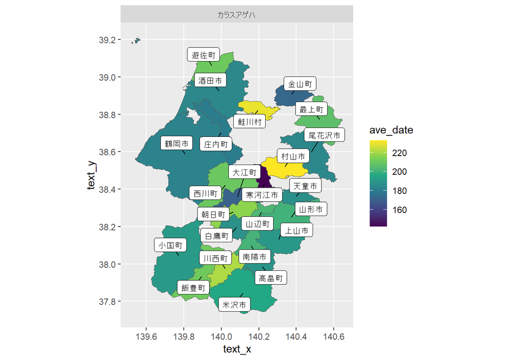

### ミヤマカラスアゲハ

**早い記録**

```
     採集日時 累計日数 市町村名         詳細地名 個体数   採集者
1  1999-04-06       96   朝日村       朝日村倉沢      1 本木俊一
2  1991-04-24      114   鶴岡市       鶴岡市大山      1 山本英夫
3  1982-04-27      117   山形市     山形市西蔵王      1 黒沼孝一
4  1991-05-02      122   酒田市       酒田市生石      1 遠藤弘夫
5  1952-05-04      125   山形市     山形市二口峠      1 渡辺秦平
6  1998-05-11      131   山形市     山形市上宝沢      1 木俣　繁
7  1963-05-12      132   山形市       山形市盃山      1 高橋清志
8  2003-05-12      132   鶴岡市 鶴岡市高館山山頂      1 本木俊一
9  2003-05-18      138   西川町     西川町弓張平      1 武田　隆
10 1985-05-19      139   小国町       小国町木落      1 武田　隆
11 2009-05-19      139   鶴岡市 鶴岡市高館山山頂      1 本木俊一
           引用文献 備考
1   出羽のむしＮｏ6
2  鶴岡自然誌Ｎｏ15
3    山形博物昆虫10
4          山昆誌22
5           泉Ｎｏ6
6    山形博物昆虫10
7        盃山の蝶類
8   出羽のむしＮｏ6
9   出羽のむしＮｏ5
10  出羽のむしＮｏ5
11  出羽のむしＮｏ6
```

**遅い記録**

```
    採集日時 累計日数 市町村名                     詳細地名 個体数   採集者
1 2017-09-26      269   小国町 小国町カイラギ小屋～地神北峰      1 草刈広一
2 2009-09-20      263   山形市                   山形市盃山      1 高橋清志
3 1996-09-08      252   鶴岡市               温海町関川林道      1 本木俊一
4 1963-09-01      244   山形市               山形市蔵王温泉      1 長岡久人
5 1981-09-01      244   山形市                 山形市西蔵王      1 黒沼孝一
6 1976-08-29      242   山形市               山形市蔵王温泉      1 武田　隆
7 2011-08-29      241   鶴岡市           鶴岡市（温海）一霞      1 本木俊一
8 1981-08-28      240   山形市             山形市山寺奥山寺      1 武田　隆
9 2005-08-28      240   朝日村       朝日村月山施薬小屋附近      1 大高　力
          引用文献 備考
1 寒河江川流域No12
2  出羽のむしＮｏ7
3  出羽のむしＮｏ6
4       盃山の蝶類
5   山形博物昆虫10
6  出羽のむしＮｏ5
7 鶴岡自然誌Ｎｏ15
8  出羽のむしＮｏ5
9  出羽のむしＮｏ6
```

**生息している市町村**

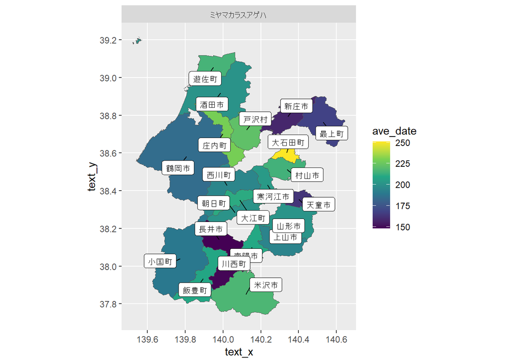

### アオスジアゲハ

**早い記録**

```
     採集日時 累計日数 市町村名                詳細地名 個体数   採集者
1  1960-05-15      136   鶴岡市              鶴岡市加茂      1 本木俊一
2  1990-05-20      140   鶴岡市        藤島町藤島古楯跡      1 山本英夫
3  2016-05-23      144   酒田市      酒田市八森自然公園      1 岡部光一
4  2000-05-26      147   鶴岡市            鶴岡市千石町      1 本木俊一
5  1991-05-28      148   酒田市      酒田市広野字十五転      1 遠藤弘夫
6  2011-05-31      151   遊佐町                  遊佐町      1 黒沼孝一
7  1989-06-06      157   鶴岡市          鶴岡市大山馬町      1 山本英夫
8  2011-06-12      163   酒田市          酒田市飛島勝浦      3 本木俊一
9  1953-06-15      166   鶴岡市 鶴岡市八坂町(現大東町）      1 本木俊一
10 1993-06-22      173   遊佐町              遊佐町広野      1 山本英夫
           引用文献        備考
1   出羽のむしＮｏ6
2  鶴岡自然誌Ｎｏ15
3  出羽のむしＮｏ13
4   出羽のむしＮｏ6
5          山昆誌22
6    山形博物昆虫10
7  鶴岡自然誌Ｎｏ15
8  鶴岡自然誌Ｎｏ15 内エサキ型1
9   出羽のむしＮｏ6
10 鶴岡自然誌Ｎｏ15
```

**遅い記録**

```
    採集日時 累計日数 市町村名                         詳細地名 個体数   採集者
1 1960-10-02      276   鶴岡市          鶴岡市八坂町(現大東町）      1 本木俊一
2 1960-10-01      275   鶴岡市                     鶴岡市千石町      1 本木俊一
3 2003-09-22      265   鶴岡市                     温海町大岩川      2 本木俊一
4 2005-09-16      259   遊佐町                       遊佐町女鹿      1 大高　力
5 2004-09-03      247   鶴岡市                     温海町小岩川      1 本木俊一
6 2005-09-03      246   天童市                     天童市舞鶴山      1 武田　隆
7 1972-08-27      240   山形市                   山形市新山林道      1 横倉　明
8 1972-08-27      240   山形市 山形市釈迦堂馬見ケ崎川（左岸）　      1 武田　隆
9 1991-08-25      237   鶴岡市             温海町温海天魄山山頂      1 山本英夫
          引用文献 備考
1  出羽のむしＮｏ6
2  出羽のむしＮｏ6
3  出羽のむしＮｏ6
4  出羽のむしＮｏ6
5  出羽のむしＮｏ6
6  出羽のむしＮｏ5
7  らふぁえりすNo3
8  出羽のむしＮｏ5
9 鶴岡自然誌Ｎｏ15
```

**生息している市町村**

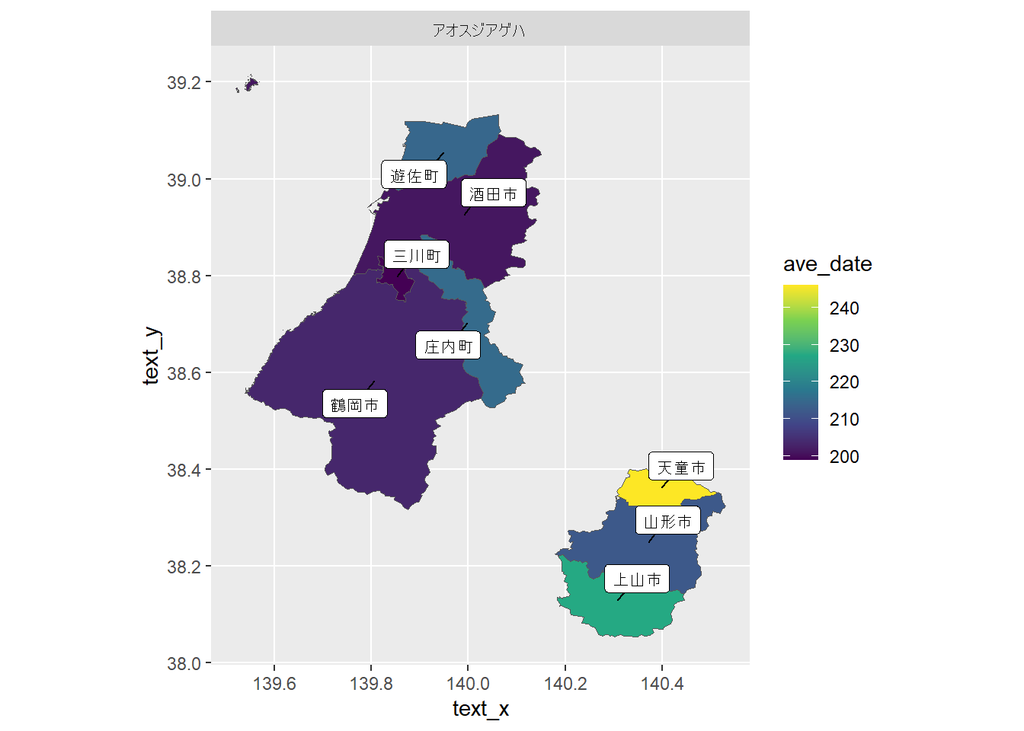

### ホソオチョウ

**早い記録**

```
     採集日時 累計日数 市町村名                                    詳細地名
1  2017-05-02      122   山形市                     幼虫令4令3exs5令1ex確認
2  2017-05-03      123   山形市                     幼虫令4令3exs5令1ex確認
3  2017-05-06      126   山形市                     幼虫令4令3exs5令1ex確認
4  2017-05-07      127   山形市                     幼虫令4令3exs5令1ex確認
5  2016-06-14      166   山形市              山形市馬見ケ崎馬見ケ崎川河川敷
6  2017-06-18      169   山形市                     幼虫令4令3exs5令1ex確認
7  2017-06-20      171   山形市                     幼虫令4令3exs5令1ex確認
8  2017-06-23      174   山形市                     幼虫令4令3exs5令1ex確認
9  2017-06-24      175   山形市                     幼虫令4令3exs5令1ex確認
10 2017-06-25      176   山形市                     幼虫令4令3exs5令1ex確認
   個体数   採集者         引用文献 備考
1       2 大高　力 出羽のむしＮｏ13
2       3 大高　力 出羽のむしＮｏ13
3       1 大高　力 出羽のむしＮｏ13
4       1 大高　力 出羽のむしＮｏ13
5       2 横倉　明 出羽のむしＮｏ12
6       1 大高　力 出羽のむしＮｏ13
7       3 大高　力 出羽のむしＮｏ13
8       2 大高　力 出羽のむしＮｏ13
9       3 大高　力 出羽のむしＮｏ13
10      3 大高　力 出羽のむしＮｏ13
```

**遅い記録**

```
[1] 採集日時 累計日数 市町村名 詳細地名 個体数   採集者   引用文献 備考
<0 rows> (or 0-length row.names)
```

**生息している市町村**

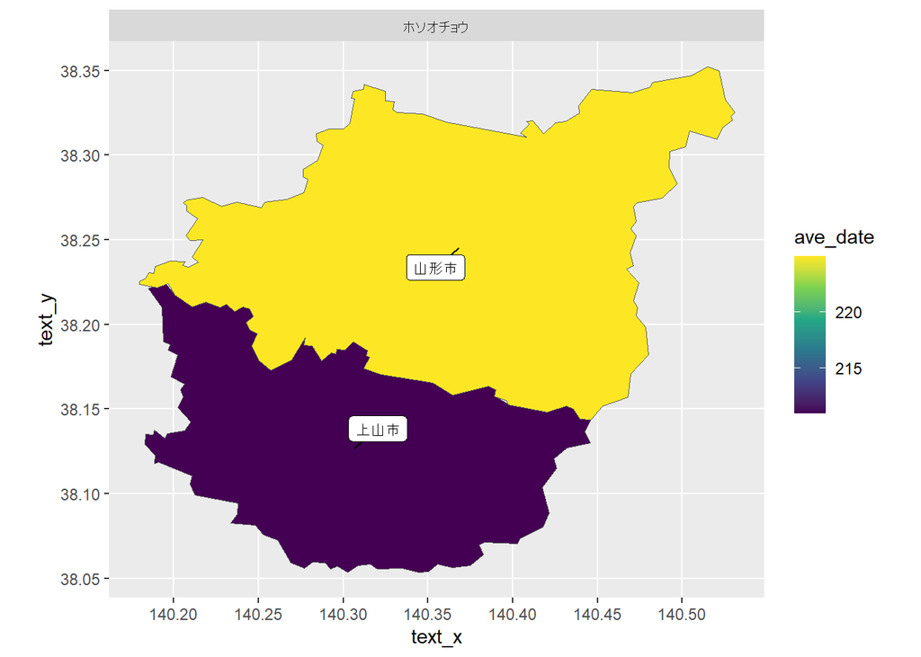

## シロチョウ科

### ヒメシロチョウ

**早い記録**

```
    採集日時 累計日数 市町村名                     詳細地名 個体数     採集者
1 1972-04-20      111   山形市                 山形市千歳山      1   横倉　明
2 2002-04-21      111   白鷹町        白鷹町荒砥甲（最上川)      7   御船藤志
3 2002-04-22      112   白鷹町      白鷹町貝生川橋（貝生川)      7   御船藤志
4 1972-04-22      113   山形市 山形市松波千歳山山麓(水田畦)      1   武田　隆
5 1969-04-23      113   酒田市                 酒田市大森山      1 白畑孝太郎
6 2002-04-24      114   長井市                 長井市館町北      8   田村伸明
7 2002-04-28      118 尾花沢市                 尾花沢市荻袋      7   田村伸明
8 2001-04-28      118   川西町       川西町尾長島（鬼面川）      1   御船藤志
         引用文献 備考
1 らふぁえりすNo3
2   出羽のむしN02
3   出羽のむしN02
4   出羽のむしNo2
5  山形博物昆虫10
6   出羽のむしN02
7   出羽のむしNo2
8   出羽のむしN02
```

**遅い記録**

```
    採集日時 累計日数 市町村名                       詳細地名 個体数   採集者
1 1968-10-02      276   米沢市                     米沢市館山      1 山谷文仁
2 2002-09-21      264   白鷹町                     白鷹町荒砥      1 桐生康夫
3 1973-09-15      258   村山市   村山市大久保最上川(右岸堤防)      1 武田　隆
4 2009-09-14      257 大石田町               大石田町丹生川橋      2 大高　力
5 2003-09-10      253 尾花沢市 尾花沢市安久土丹生川(右岸堤防)      1 横倉　明
6 1986-09-07      250   米沢市             米沢市八幡原天王川      1 岡野光一
7 2003-09-06      249 尾花沢市           尾花沢市安久土丹生川      2 大高　力
8 2003-09-04      247   白鷹町              白鷹町荒砥（思川)      4 本木俊一
            引用文献 備考
1    らふぁえりすNo3
2 山昆大賞ノメネ－ト
3      出羽のむしNo2
4      出羽のむしNo8
5      出羽のむしNo2
6           山昆誌16
7      出羽のむしNo8
8      出羽のむしN02
```

**生息している市町村**

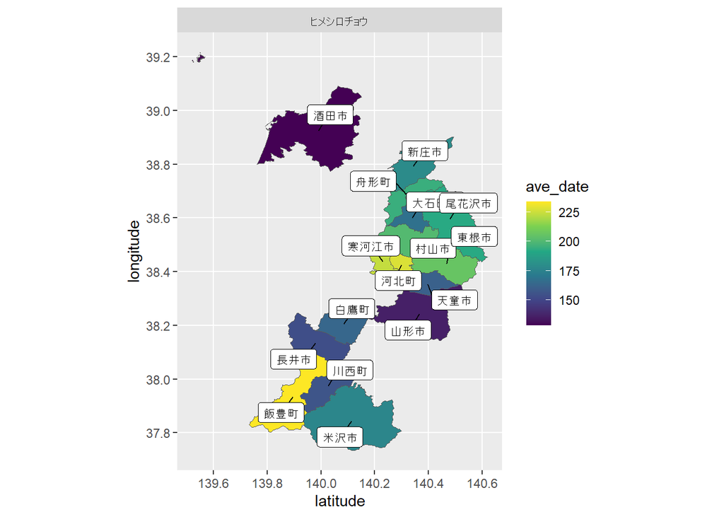

### キタキチョウ

**早い記録**

```
    採集日時 累計日数 市町村名             詳細地名 個体数           採集者
1 2003-03-25       84   鶴岡市       鶴岡市大山公園      1         本木俊一
2 1955-04-10      100   山形市           山形市盃山      1 伊藤、大宮、渡辺
3 2008-04-16      107   村山市 村山市楯山とその周辺      1         土谷義幸
4 1963-04-28      118   山形市           山形市盃山      1         長岡久人
5 2005-05-01      121   山形市           山形市盃山      1         長岡久人
6 2008-05-01      122   村山市 村山市楯山とその周辺      2         土谷義幸
7 2007-05-07      127   村山市 村山市楯山とその周辺      1         土谷義幸
8 1993-05-07      127   山形市           山形市盃山      1         島津昌弘
9 1948-05-12      133   山形市           山形市滝山      1         早坂公夫
               引用文献 備考
1         出羽のむしNo2
2 ＢＡＢＯＹＫＡ　Ｎｏ7
3       出羽のむしＮｏ6
4       出羽のむしＮｏ6
5      出羽のむしＮｏ11
6       出羽のむしＮｏ6
7       出羽のむしＮｏ6
8         出羽のむしNo2
9        山形博物昆虫10
```

**遅い記録**

```
    採集日時 累計日数 市町村名     詳細地名 個体数   採集者         引用文献
1 2010-12-02      336   山辺町   山辺町下原      1 大高　力    出羽のむしNo8
2 2010-12-01      335   山辺町   山辺町下原      1 大高　力    出羽のむしNo8
3 1961-11-28      332   米沢市 米沢市小野川      1 本木俊一    出羽のむしNo2
4 1960-11-23      328   東根市 東根市水晶山      1 小倉住夫 趣味の昆虫2-1～2
5 2002-11-23      327   鶴岡市 鶴岡市千石町      1 本木俊一    出羽のむしNo2
6 1987-11-16      320   米沢市 米沢市八幡原      3 岡村光一    出羽のむしNo2
7 1962-11-12      316   酒田市   酒田市生石      1 岡部光一    出羽のむしNo2
8 1993-11-08      312   遊佐町   遊佐町落伏      1 岡部光一    出羽のむしNo2
  備考
1
2
3
4
5
6
7
8
```

**生息している市町村**

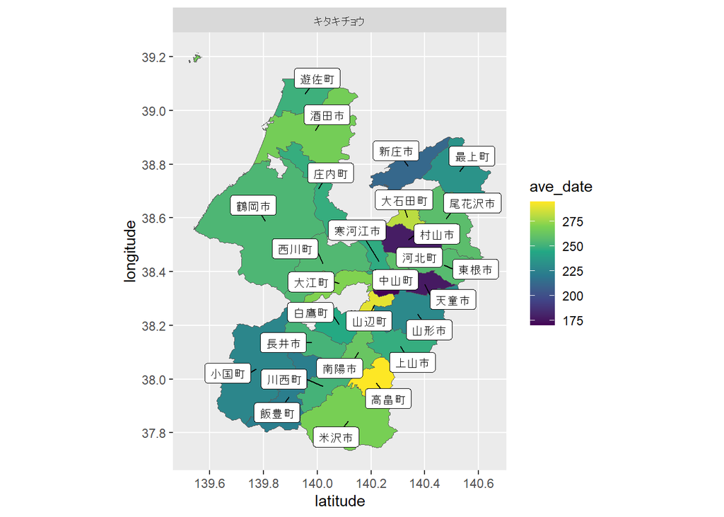

### ツマグロキチョウ

**早い記録**

```
    採集日時 累計日数 市町村名     詳細地名 個体数     採集者       引用文献
1 1950-08-31      243   酒田市 酒田市亀ケ崎      1 五十嵐敬司 出羽のむし創刊
2 1961-11-04      308   酒田市   酒田市坂本      1 白畑孝太郎 山形博物昆虫10
  備考
1
2
```

**遅い記録**

```
    採集日時 累計日数 市町村名     詳細地名 個体数     採集者       引用文献
1 1961-11-04      308   酒田市   酒田市坂本      1 白畑孝太郎 山形博物昆虫10
2 1950-08-31      243   酒田市 酒田市亀ケ崎      1 五十嵐敬司 出羽のむし創刊
  備考
1
2
```

**生息している市町村**

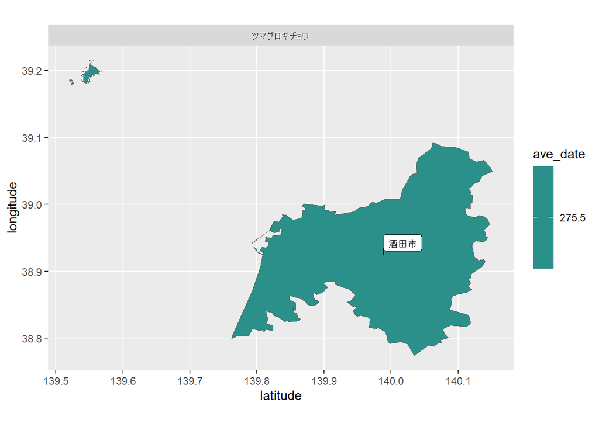

### スジボソヤマキチョウ

**早い記録**

```
     採集日時 累計日数 市町村名     詳細地名 個体数   採集者        引用文献
1  1990-03-11       70   鶴岡市 鶴岡市高館山      1 横倉　明   出羽のむしNo2
2  1971-03-21       80   山形市   山形市盃山      1 横倉　明   出羽のむしNo2
3  1971-03-21       80   山形市 山形市高原町      1 武田　隆   出羽のむしNo2
4  1971-03-28       87   山形市   山形市盃山      1 長岡久人 出羽のむしＮｏ7
5  1971-03-28       87   山形市 山形市沼ノ辺      1 横倉　明   出羽のむしNo2
6  1998-03-29       88   鶴岡市 鶴岡市高館山      1 武田　隆   出羽のむしNo2
7  1964-03-29       89   山形市   山形市盃山      1 長岡久人 出羽のむしＮｏ6
8  1964-03-29       89   酒田市   酒田市生石      2 岡部光一   出羽のむしNo2
9  1973-03-31       90   山形市   山形市盃山      2 横倉　明   出羽のむしNo2
10 1973-03-31       90   山形市 山形市沼ノ辺      1 武田　隆   出羽のむしNo2
   備考
1
2
3
4
5
6
7
8
9
10
```

**遅い記録**

```
     採集日時 累計日数 市町村名              詳細地名 個体数     採集者
1  1966-10-30      303   山形市            山形市盃山      1   武田典雄
2  2004-10-16      290   鶴岡市          温海町槙ノ代      1   本木俊一
3  2002-10-11      284   鶴岡市      温海町大岩川沢山      1   本木俊一
4  2001-10-07      280   鶴岡市      温海町大岩川沢山      1   本木俊一
5  2001-10-07      280   鶴岡市          温海町大岩川      3   島津昌弘
6  1973-10-04      277   山形市            山形市盃山      4   長岡久人
7  2001-10-04      277   鶴岡市      温海町大岩川沢山      2   本木俊一
8  1987-10-03      276   米沢市          米沢市八幡原      1   岡村光一
9  1969-10-03      276   酒田市          酒田市大森山      3 白畑孝太郎
10 1999-10-02      275   鶴岡市 温海町温海岳(alt650m)      5   本木俊一
          引用文献 備考
1    出羽のむしNo2
2    出羽のむしNo2
3    出羽のむしNo2
4    出羽のむしNo2
5    出羽のむしNo2
6  出羽のむしＮｏ7
7    出羽のむしNo2
8    出羽のむしNo2
9  山形県博物昆虫1
10   出羽のむしNo2
```

**生息している市町村**

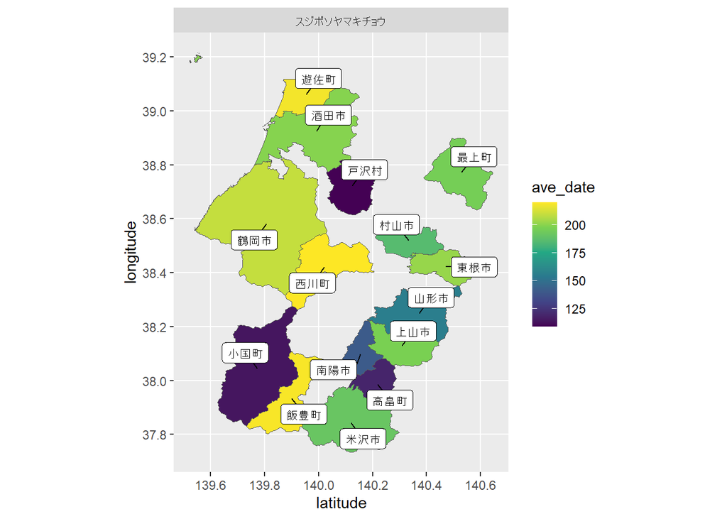

### モンキチョウ

**早い記録**

```
    採集日時 累計日数 市町村名             詳細地名 個体数   採集者
1 1991-04-19      109   山形市           山形市高原      2 田村伸明
2 1975-04-25      115   山形市 山形市滑川林戸沢林道      1 武田　隆
3 1958-04-28      118   鶴岡市         温海町小岩川      2 大石道明
4 1972-04-29      120   山形市           山形市盃山      1 長岡久人
5 1987-05-01      121   米沢市     米沢市川西天王川      2 岡村光一
6 1998-05-02      122   山形市           山形市盃山      1 武田典雄
7 1999-05-02      122   大蔵村           大蔵村清水      1 本木俊一
       引用文献 備考
1 出羽のむしNo2
2 出羽のむしNo2
3  山形県博物館
4    盃山の蝶類
5 出羽のむしNo2
6 出羽のむしNo2
7 出羽のむしNo2
```

**遅い記録**

```
     採集日時 累計日数 市町村名     詳細地名 個体数   採集者         引用文献
1  2015-12-15      349   山形市 山形市中桜田      2 大高　力   出羽のむしNo11
2  2015-12-14      348   山形市 山形市中桜田      1 島津昌弘   出羽のむしNo11
3  2015-12-12      346   山形市 山形市中桜田      2 大高　力   出羽のむしNo11
4  2015-12-09      343   山形市 山形市中桜田      2 大高　力   出羽のむしNo11
5  2015-12-08      342   山形市 山形市中桜田      1 大高　力   出羽のむしNo11
6  2015-12-07      341   山形市 山形市中桜田      1 大高　力   出羽のむしNo11
7  2015-12-02      336   山形市 山形市中桜田      1 島津昌弘   出羽のむしNo11
8  2005-11-26      330   山形市 山形市船町橋      1 大高　力    出羽のむしNo8
9  2009-11-25      329   中山町 中山町達磨寺      1 大高　力    出羽のむしNo6
10 1960-11-23      328   東根市 東根市水晶山      1 小倉住夫 趣味の昆虫2-1～1
   備考
1
2
3
4
5
6
7
8
9
10
```

**生息している市町村**

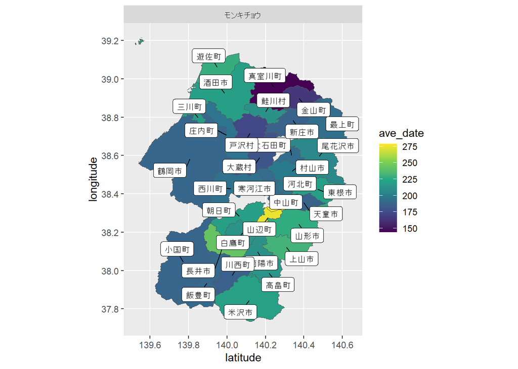

### ツマキチョウ

**早い記録**

```
     採集日時 累計日数 市町村名                   詳細地名 個体数   採集者
1  2002-04-03       93   村山市                 村山市長嶋      1 田村伸明
2  2001-04-11      101   鶴岡市 鶴岡市金峰山(楠公館コ－ス)      1 本木俊一
3  1954-04-12      102   山形市                 山形市盃山      1 伊藤義穂
4  1997-04-17      107   長井市               長井市伊佐沢      1 本木俊一
5  1991-04-17      107   酒田市             八幡町八森公園      1 相蘇　尚
6  2009-04-19      109   中山町               中山町達磨寺      3 大高　力
7  1998-04-19      109   酒田市             八幡町八森公園      2 相蘇　尚
8  2002-04-20      110   鶴岡市                 櫛引町松根      1 本木俊一
9  1963-04-21      111   山形市                 山形市盃山      3 長岡久人
10 2002-04-21      111   白鷹町     白鷹町荒砥甲（最上川）      6 御船藤志
11 2001-04-21      111   酒田市             八幡町八森公園      1 相蘇　尚
          引用文献 備考
1    出羽のむしNo2
2    出羽のむしNo2
3      いずみＮｏ9
4    出羽のむしNo2
5    出羽のむしNo2
6    出羽のむしNo8
7    出羽のむしNo2
8    出羽のむしNo2
9  出羽のむしＮｏ6
10   出羽のむしNo2
11   出羽のむしNo2
```

**遅い記録**

```
    採集日時 累計日数 市町村名                     詳細地名 個体数     採集者
1 2011-06-27      178   米沢市                 米沢市下新田      1   島津昌弘
2 1967-06-27      178 真室川町               真室川町神ケ沢      1 白畑孝太郎
3 2004-06-23      175   遊佐町                   遊佐町岩野      2   相蘇　尚
4 2006-06-18      169   鶴岡市               鶴岡市大網牧場      1   大高　力
5 2011-06-15      166   高畠町                 高畠町糠ノ目      2   島津昌弘
6 2011-06-15      166   鶴岡市                 鶴岡市温海川      1   大高　力
7 1981-06-14      165   米沢市 米沢市上竹井天王川(左岸堤防)      1   武田　隆
8 1974-06-14      165   小国町                       小国町      1   山谷文仁
                引用文献 備考
1          出羽のむしNo8
2        山形県博物昆虫1
3          出羽のむしNo2
4          出羽のむしNo8
5          出羽のむしNo8
6          出羽のむしNo8
7          出羽のむしNo2
8 ファウナウキタムＮｏ55
```

**生息している市町村**

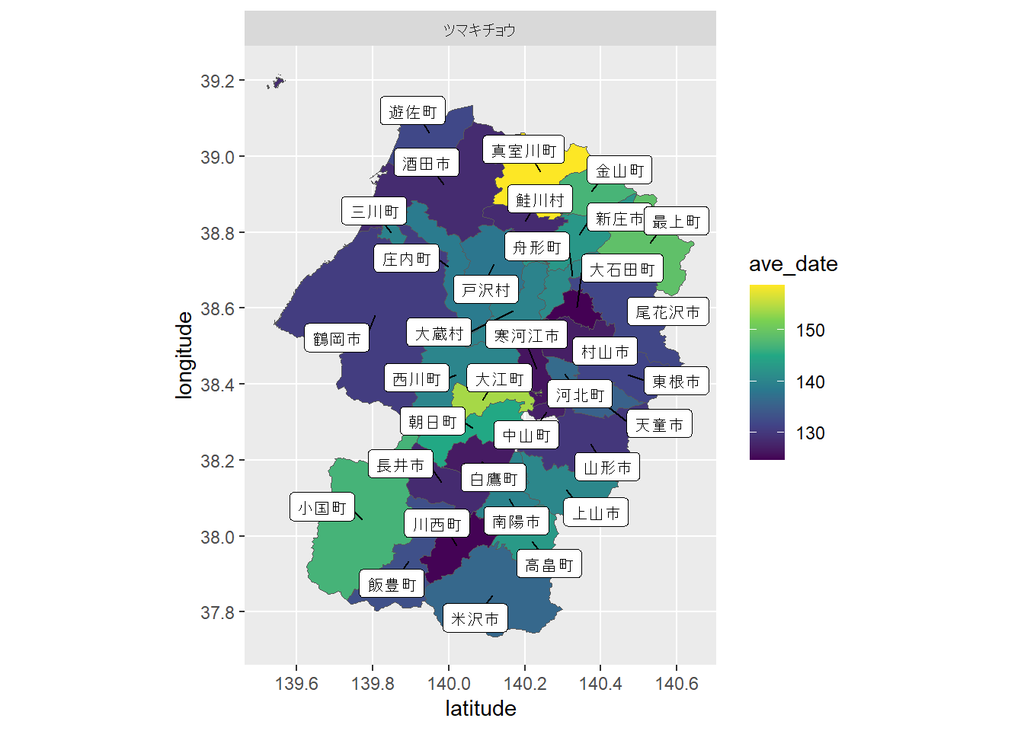

### ヤマトスジグロシロチョウ

**早い記録**

```
    採集日時 累計日数 市町村名             詳細地名 個体数     採集者
1 2009-03-10       69   山形市         山形市東青田      1   紺野広昭
2 1967-04-02       92   白鷹町           白鷹町滝野      1   加藤和彦
3 1992-04-02       93   鶴岡市           鶴岡市高坂      1   山本英夫
4 2008-04-06       97   村山市 村山市楯山とその周辺      2   土谷義幸
5 1967-04-07       97   白鷹町           白鷹町菖蒲      1   加藤和彦
6 1967-04-10      100   白鷹町           白鷹町菖蒲      1   加藤和彦
7 1960-04-13      104   山形市         山形市千歳山      1   大石道明
8 2008-04-16      107   村山市 村山市楯山とその周辺      1   土谷義幸
9 1969-04-23      113   酒田市         酒田市大森山      1 白畑孝太郎
          引用文献         備考
1  出羽のむしＮｏ6 最も早い記録
2  山形県博物昆虫1
3 鶴岡自然誌Ｎｏ15
4  出羽のむしＮｏ6
5  山形県博物昆虫1
6  山形県博物昆虫1
7     山形県博物館
8  出羽のむしＮｏ6
9  山形県博物昆虫1
```

**遅い記録**

```
     採集日時 累計日数 市町村名             詳細地名 個体数     採集者
1  2014-10-08      281   山形市         山形市村木沢      1   大高　力
2  1973-10-04      277   山形市           山形市盃山      1   長岡久人
3  2011-09-28      271   山形市         山形市中桜田      1   大高　力
4  1967-09-26      269   白鷹町         白鷹町八幡岡      1   加藤和彦
5  2011-09-23      266   山形市   山形市上桜田悠創丘      1   大高　力
6  2010-09-18      261   村山市 村山市楯山とその周辺      1   土谷義幸
7  1973-09-16      259   山形市           山形市盃山      8   長岡久人
8  2015-09-16      259   山形市         山形市冨神山      1   大高　力
9  1998-09-16      259   朝日村           朝日村落合      1   山本英夫
10 1959-09-15      258   酒田市         酒田市飯森山      1 白畑孝太郎
11 2015-09-15      258   酒田市           酒田市升田      1   岡部光一
           引用文献 備考
1  出羽のむしＮｏ10
2   出羽のむしＮｏ7
3   出羽のむしＮｏ8
4   山形県博物昆虫1
5   出羽のむしＮｏ8
6      楯山のチョウ
7   出羽のむしＮｏ7
8  出羽のむしＮｏ11
9  鶴岡自然誌Ｎｏ15
10  山形県博物昆虫1
11 出羽のむしＮｏ13
```

**生息している市町村**

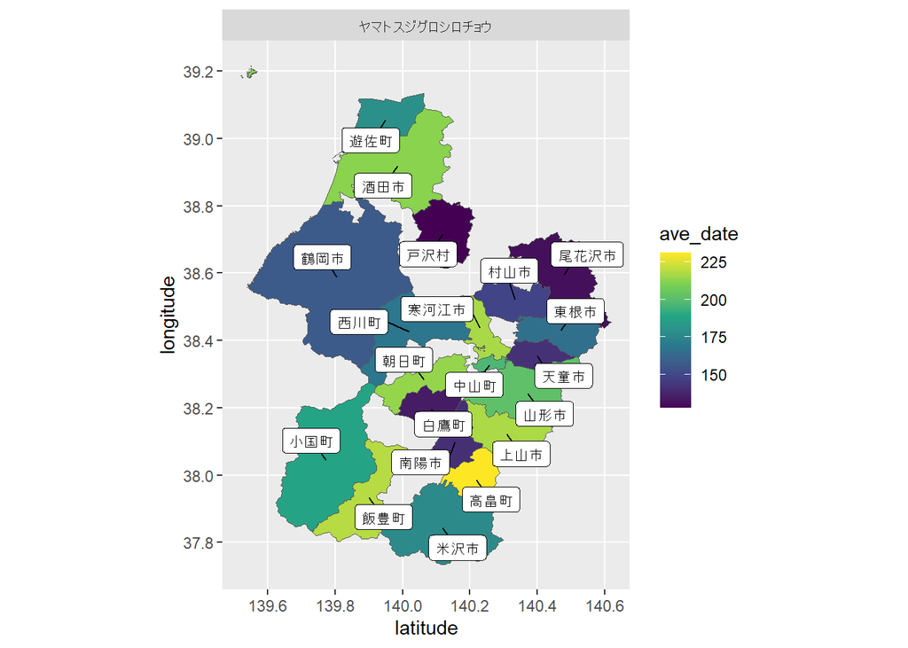

### スジグロシロチョウ

**早い記録**

```
     採集日時 累計日数 市町村名         詳細地名 個体数   採集者
1  1971-03-28       87   山形市       山形市盃山      1 長岡久人
2  1954-04-11      101   山形市       山形市盃山      1 伊藤義穂
3  1960-04-13      104   山形市     山形市千歳山      2 大石道明
4  1989-04-14      104   鶴岡市     鶴岡市金峰山      1 山本英夫
5  2014-04-17      107   山形市     山形市妙見寺      1 大高　力
6  1990-04-18      108   鶴岡市       鶴岡市岡山      2 山本英夫
7  1990-04-19      109   上山市     上山市宮川原      2 小野精美
8  1989-04-19      109   遊佐町       遊佐町蕨岡      1 山本英夫
9  1938-04-20      110   山形市 山形市師範元農場      1 大國五郎
10 1990-04-20      110   鶴岡市       鶴岡市行沢      1 山本英夫
              引用文献 備考
1      らふぁえりすNo3
2  しゅめてりんげＮ０3
3       山形博物昆虫10
4     鶴岡自然誌Ｎｏ15
5     出羽のむしＮｏ10
6     鶴岡自然誌Ｎｏ15
7             山昆誌20
8     鶴岡自然誌Ｎｏ15
9                 眞琴
10    鶴岡自然誌Ｎｏ15
```

**遅い記録**

```
    採集日時 累計日数 市町村名           詳細地名 個体数     採集者
1 2014-11-11      315   山形市       山形市中桜田      1   高橋清志
2 2015-10-17      290   山形市       山形市中桜田      1   大高　力
3 2014-10-12      285   朝日町       朝日町西舟渡      1   大高　力
4 2014-10-08      281   山形市 山形市上桜田悠創丘      1   大高　力
5 2014-10-07      280   山形市       山形市中桜田      1   大高　力
6 1973-10-04      277   山形市         山形市盃山      4   長岡久人
7 1969-10-02      275   酒田市       酒田市大森山      1 白畑孝太郎
8 1970-10-01      274   西川町         西川町志津      1 白畑孝太郎
9 2012-09-18      262   朝日町         朝日町川通      1   大高　力
          引用文献 備考
1 出羽のむしＮｏ11
2 出羽のむしＮｏ11
3 出羽のむしＮｏ10
4 出羽のむしＮｏ10
5 出羽のむしＮｏ10
6  出羽のむしＮｏ7
7  山形県博物昆虫1
8  山形県博物昆虫1
9  出羽のむしＮｏ8
```

**生息している市町村**

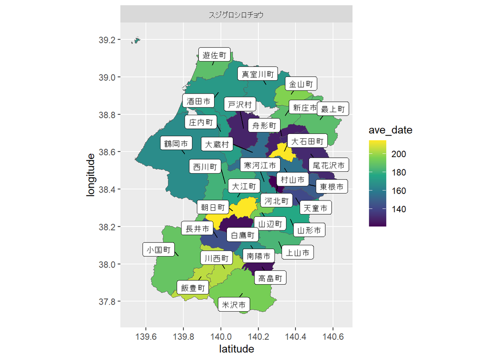

### モンシロチョウ

**早い記録**

```
    採集日時 累計日数 市町村名     詳細地名 個体数   採集者      引用文献 備考
1 1953-03-01       60   山形市   山形市盃山      1 梅津　晋  蔵王山系の蝶
2 1976-03-14       74   山形市 山形市和合町      1 武田　隆 出羽のむしNo2
3 2008-03-15       75   山形市   山形市沼木      1 武田典雄 出羽のむしNo5
4 1997-03-21       80   山形市 山形市久保田      1 横倉　明 出羽のむしNo2
```

**遅い記録**

```
    採集日時 累計日数 市町村名             詳細地名 個体数   採集者
1 2014-11-28      332   鶴岡市  鶴岡市大岩川alt.30m      1 本木俊一
2 2005-11-26      330   山形市           山形市悪戸      1 大高　力
3 2013-11-24      328   山形市    山形市城西町5丁目      1 大高　力
4 1954-11-14      318   山形市           山形市盃山      1 梅津　晋
5 2004-10-16      290   鶴岡市   温海町小岩川小川内      1 本木俊一
6 1981-10-11      284   山形市 山形市釈迦堂中野沢口      1 武田　隆
          引用文献 備考
1 鶴岡自然誌Ｎｏ18
2    出羽のむしNo7
3   出羽のむしNo10
4  らふぁえりすNo3
5    出羽のむしNo2
6    出羽のむしNo2
```

**生息している市町村**

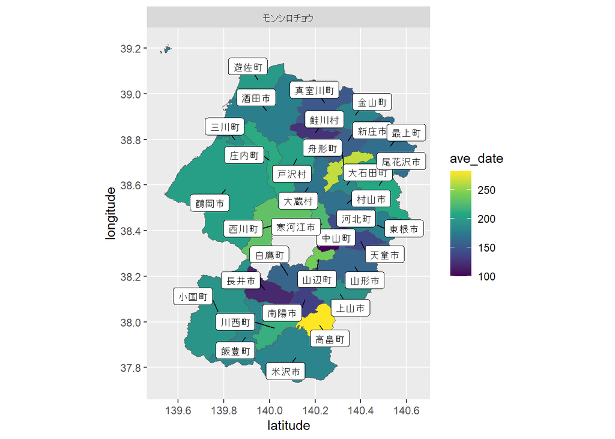